# Decorrelation-Based Feature Discovery: NHNES Males Depression

## 1.6 The heatmap of the decorrelated data

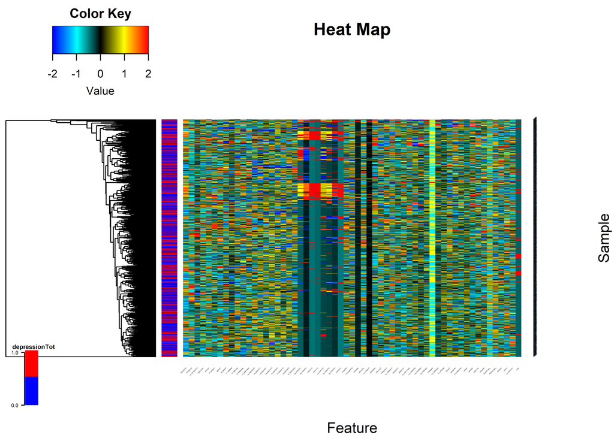

```r
if (!largeSet)
{

  hm <- heatMaps(data=DEdataframe[1:numsub,],
                 Outcome=outcome,
                 Scale=TRUE,
                 hCluster = "row",
                 cexRow = cexheat,
                 cexCol = cexheat,
                 srtCol=45,
                 srtRow=45,
                 xlab="Feature",
                 ylab="Sample")
  par(op)
}
```

## 1.7 The correlation matrix after decorrelation

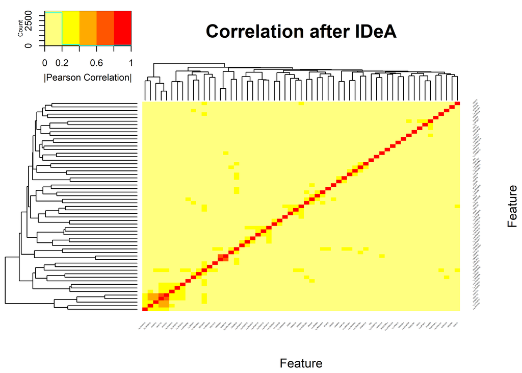

```r
if (!largeSet)
{

  cormat <- cor(DEdataframe[,varlistc],method="pearson")
  cormat[is.na(cormat)] <- 0

  gplots::heatmap.2(abs(cormat),
                    trace = "none",
                    mar = c(5,5),
                    col=rev(heat.colors(5)),
                    main = "Correlation after IDeA",
                    cexRow = cexheat,
                    cexCol = cexheat,
                     srtCol=45,
                     srtRow=45,
                    key.title=NA,
                    key.xlab="|Pearson Correlation|",
                    xlab="Feature", ylab="Feature")

  par(op)
  diag(cormat) <- 0
  print(max(abs(cormat)))
}
```

[1] 0.6835785

## 1.8 U-MAP Visualization of features

```r
if (nrow(dataframe) < 1000)
{
  classes <- unique(dataframe[1:numsub,outcome])
  raincolors <- rainbow(length(classes))
  names(raincolors) <- classes
  datasetframe.umap = umap(scale(dataframe[1:numsub,varlist]),n_components=2)
  plot(datasetframe.umap$layout,xlab="U1",ylab="U2",main="UMAP: Original",t='n')
  text(datasetframe.umap$layout,labels=dataframe[1:numsub,outcome],col=raincolors[dataframe[1:numsub,outcome]+1])
}
```

### 1.8.2 The decorralted UMAP

```r
if (nrow(dataframe) < 1000)
{

  datasetframe.umap = umap(scale(DEdataframe[1:numsub,varlistc]),n_components=2)
  plot(datasetframe.umap$layout,xlab="U1",ylab="U2",main="UMAP: After IDeA",t='n')
  text(datasetframe.umap$layout,labels=DEdataframe[1:numsub,outcome],col=raincolors[DEdataframe[1:numsub,outcome]+1])
}
```

## 1.9 Univariate Analysis

### 1.9.1 Univariate

```r
univarRAW <- uniRankVar(varlist,
               paste(outcome,"~1"),
               outcome,
               dataframe,
               rankingTest="AUC")



univarDe <- uniRankVar(varlistc,
               paste(outcome,"~1"),
               outcome,
               DEdataframe,
               rankingTest="AUC",
               )
```

### 1.9.2 Final Table

```r
univariate_columns <- c("caseMean","caseStd","controlMean","controlStd","controlKSP","ROCAUC")

##topfive
topvar <- c(1:length(varlist)) <= TopVariables
pander::pander(univarRAW$orderframe[topvar,univariate_columns])
```

|  | caseMean | caseStd | controlMean | controlStd | controlKSP | ROCAUC |
| --- | --- | --- | --- | --- | --- | --- |
| **BPXML1** | 1.49e+02 | 1.50e+01 | 1.51e+02 | 1.55e+01 | 0.00e+00 | 0.541 |
| **WTMEC2YR** | 4.55e+04 | 3.35e+04 | 4.25e+04 | 3.43e+04 | 0.00e+00 | 0.540 |
| **WTINT2YR** | 4.42e+04 | 3.27e+04 | 4.13e+04 | 3.35e+04 | 0.00e+00 | 0.540 |
| **LBDHDD** | 4.68e+01 | 1.39e+01 | 4.83e+01 | 1.39e+01 | 8.98e-09 | 0.539 |
| **LBDBANO** | 5.14e-02 | 5.29e-02 | 4.33e-02 | 5.04e-02 | 0.00e+00 | 0.537 |
| **RIDAGEYR** | 4.69e+01 | 1.79e+01 | 4.89e+01 | 1.69e+01 | 2.66e-05 | 0.536 |
| **LBXBAPCT** | 7.68e-01 | 3.70e-01 | 7.23e-01 | 3.30e-01 | 0.00e+00 | 0.534 |
| **URXUCR.x** | 1.44e+02 | 8.12e+01 | 1.36e+02 | 8.18e+01 | 7.89e-06 | 0.532 |
| **bpresSYM** | 1.24e+02 | 1.59e+01 | 1.25e+02 | 1.57e+01 | 7.68e-06 | 0.529 |
| **URXUMA** | 6.17e+01 | 3.02e+02 | 4.78e+01 | 3.83e+02 | 0.00e+00 | 0.529 |

```r
topLAvar <- univarDe$orderframe$Name[str_detect(univarDe$orderframe$Name,"La_")]
topLAvar <- unique(c(univarDe$orderframe$Name[topvar],topLAvar[1:as.integer(TopVariables/2)]))
finalTable <- univarDe$orderframe[topLAvar,univariate_columns]

theLaVar <- rownames(finalTable)[str_detect(rownames(finalTable),"La_")]

pander::pander(univarDe$orderframe[topLAvar,univariate_columns])
```

|  | caseMean | caseStd | controlMean | controlStd | controlKSP | ROCAUC |
| --- | --- | --- | --- | --- | --- | --- |
| **La_BMXBMI** | 5.51e+01 | 5.80e-01 | 5.50e+01 | 5.98e-01 | 0.00e+00 | 0.544 |
| **WTINT2YR** | 4.42e+04 | 3.27e+04 | 4.13e+04 | 3.35e+04 | 0.00e+00 | 0.540 |
| **La_BMXWAIST** | 9.71e+01 | 4.76e+00 | 9.64e+01 | 4.97e+00 | 8.59e-01 | 0.540 |
| **LBDHDD** | 4.68e+01 | 1.39e+01 | 4.83e+01 | 1.39e+01 | 8.98e-09 | 0.539 |
| **LBDBANO** | 5.14e-02 | 5.29e-02 | 4.33e-02 | 5.04e-02 | 0.00e+00 | 0.537 |
| **La_MGDCGSZ** | 1.09e+02 | 1.66e+01 | 1.12e+02 | 1.61e+01 | 8.93e-01 | 0.536 |
| **RIDAGEYR** | 4.69e+01 | 1.79e+01 | 4.89e+01 | 1.69e+01 | 2.66e-05 | 0.536 |
| **LBXBAPCT** | 7.68e-01 | 3.70e-01 | 7.23e-01 | 3.30e-01 | 0.00e+00 | 0.534 |
| **URXUCR.x** | 1.44e+02 | 8.12e+01 | 1.36e+02 | 8.18e+01 | 7.89e-06 | 0.532 |
| **La_BPXML1** | 1.31e+02 | 1.36e+01 | 1.32e+02 | 1.40e+01 | 2.30e-07 | 0.529 |
| **La_LBDEONO** | -2.90e-02 | 5.90e-02 | -2.59e-02 | 5.11e-02 | 5.38e-03 | 0.522 |

```r
dc <- getLatentCoefficients(DEdataframe)
fscores <- attr(DEdataframe,"fscore")

theSigDc <- dc[theLaVar]
names(theSigDc) <- NULL
theSigDc <- unique(names(unlist(theSigDc)))


theFormulas <- dc[rownames(finalTable)]
deFromula <- character(length(theFormulas))
names(deFromula) <- rownames(finalTable)

pander::pander(c(mean=mean(sapply(dc,length)),total=length(dc),fraction=length(dc)/(ncol(dataframe)-1)))
```

| mean | total | fraction |
| --- | --- | --- |
| 2.9 | 31 | 0.525 |

```r
allSigvars <- names(dc)



dx <- names(deFromula)[1]
for (dx in names(deFromula))
{
  coef <- theFormulas[[dx]]
  cname <- names(theFormulas[[dx]])
  names(cname) <- cname
  for (cf in names(coef))
  {
    if (cf != dx)
    {
      if (coef[cf]>0)
      {
        deFromula[dx] <- paste(deFromula[dx],
                               sprintf("+ %5.3f*%s",coef[cf],cname[cf]))
      }
      else
      {
        deFromula[dx] <- paste(deFromula[dx],
                               sprintf("%5.3f*%s",coef[cf],cname[cf]))
      }
    }
  }
}

finalTable <- rbind(finalTable,univarRAW$orderframe[theSigDc[!(theSigDc %in% rownames(finalTable))],univariate_columns])


orgnamez <- rownames(finalTable)
orgnamez <- str_remove_all(orgnamez,"La_")
finalTable$RAWAUC <- univarRAW$orderframe[orgnamez,"ROCAUC"]
finalTable$DecorFormula <- deFromula[rownames(finalTable)]
finalTable$fscores <- fscores[rownames(finalTable)]

Final_Columns <- c("DecorFormula","caseMean","caseStd","controlMean","controlStd","controlKSP","ROCAUC","RAWAUC","fscores")

finalTable <- finalTable[order(-finalTable$ROCAUC),]
pander::pander(finalTable[,Final_Columns])
```

|  | DecorFormula | caseMean | caseStd | controlMean | controlStd | controlKSP | ROCAUC | RAWAUC | fscores |
| --- | --- | --- | --- | --- | --- | --- | --- | --- | --- |
| **La_BMXBMI** | -0.310*BMXWT + 0.307*BMXHT + 1.000*BMXBMI | 5.51e+01 | 5.80e-01 | 5.50e+01 | 5.98e-01 | 0.00e+00 | 0.544 | 0.522 | -4 |
| **BPXML1** | NA | 1.49e+02 | 1.50e+01 | 1.51e+02 | 1.55e+01 | 0.00e+00 | 0.541 | 0.541 | NA |
| **WTINT2YR** |  | 4.42e+04 | 3.27e+04 | 4.13e+04 | 3.35e+04 | 0.00e+00 | 0.540 | 0.540 | 1 |
| **La_BMXWAIST** | -0.232*RIDAGEYR -0.758*BMXWT + 0.419*BMXHT + 1.000*BMXWAIST | 9.71e+01 | 4.76e+00 | 9.64e+01 | 4.97e+00 | 8.59e-01 | 0.540 | 0.519 | -3 |
| **LBDHDD** |  | 4.68e+01 | 1.39e+01 | 4.83e+01 | 1.39e+01 | 8.98e-09 | 0.539 | 0.539 | NA |
| **LBDBANO** |  | 5.14e-02 | 5.29e-02 | 4.33e-02 | 5.04e-02 | 0.00e+00 | 0.537 | 0.537 | NA |
| **La_MGDCGSZ** | + 0.470*RIDAGEYR + 1.000*MGDCGSZ | 1.09e+02 | 1.66e+01 | 1.12e+02 | 1.61e+01 | 8.93e-01 | 0.536 | 0.518 | 5 |
| **RIDAGEYR** |  | 4.69e+01 | 1.79e+01 | 4.89e+01 | 1.69e+01 | 2.66e-05 | 0.536 | 0.536 | 3 |
| **LBXBAPCT** |  | 7.68e-01 | 3.70e-01 | 7.23e-01 | 3.30e-01 | 0.00e+00 | 0.534 | 0.534 | 2 |
| **URXUCR.x** |  | 1.44e+02 | 8.12e+01 | 1.36e+02 | 8.18e+01 | 7.89e-06 | 0.532 | 0.532 | 1 |
| **La_BPXML1** | -0.379*RIDAGEYR + 1.000*BPXML1 | 1.31e+02 | 1.36e+01 | 1.32e+02 | 1.40e+01 | 2.30e-07 | 0.529 | 0.541 | 0 |
| **LBXWBCSI** | NA | 7.30e+00 | 2.01e+00 | 7.16e+00 | 2.11e+00 | 2.98e-07 | 0.528 | 0.528 | 6 |
| **BMXWT** | NA | 8.82e+01 | 2.03e+01 | 8.66e+01 | 1.99e+01 | 3.99e-07 | 0.528 | 0.528 | 5 |
| **LBDNENO** | NA | 4.30e+00 | 1.61e+00 | 4.18e+00 | 1.64e+00 | 1.25e-10 | 0.527 | 0.527 | NA |
| **BMXBMI** | NA | 2.88e+01 | 6.13e+00 | 2.83e+01 | 5.59e+00 | 4.49e-07 | 0.522 | 0.522 | NA |
| **LBXLYPCT** | NA | 2.95e+01 | 8.44e+00 | 3.02e+01 | 8.32e+00 | 5.93e-02 | 0.522 | 0.522 | 4 |
| **La_LBDEONO** | -0.283*LBXWBCSI -0.003*LBXLYPCT + 0.021*LBXMOPCT -0.054*LBXEOPCT + 0.332*LBDLYMNO + 0.279*LBDNENO + 1.000*LBDEONO | -2.90e-02 | 5.90e-02 | -2.59e-02 | 5.11e-02 | 5.38e-03 | 0.522 | 0.517 | -3 |
| **BMXWAIST** | NA | 1.02e+02 | 1.63e+01 | 1.00e+02 | 1.49e+01 | 2.99e-02 | 0.519 | 0.519 | NA |
| **LBXEOPCT** | NA | 3.06e+00 | 2.25e+00 | 3.00e+00 | 2.33e+00 | 0.00e+00 | 0.518 | 0.518 | 5 |
| **MGDCGSZ** | NA | 8.74e+01 | 1.88e+01 | 8.86e+01 | 1.79e+01 | 9.76e-01 | 0.518 | 0.518 | NA |
| **LBDEONO** | NA | 2.19e-01 | 1.96e-01 | 2.15e-01 | 1.94e-01 | 0.00e+00 | 0.517 | 0.517 | NA |
| **BMXHT** | NA | 1.75e+02 | 7.32e+00 | 1.75e+02 | 8.01e+00 | 9.66e-01 | 0.504 | 0.504 | NA |
| **LBDLYMNO** | NA | 2.10e+00 | 7.11e-01 | 2.11e+00 | 7.12e-01 | 1.15e-07 | 0.500 | 0.500 | NA |
| **LBXMOPCT** | NA | 8.77e+00 | 2.41e+00 | 8.72e+00 | 2.14e+00 | 5.08e-04 | 0.492 | 0.492 | 4 |

## 1.10 The Latent formulas

```r
theLaFormulas <- getLatentCoefficients(DEdataframe)


## Add the variable description

allvardes <- rbind(demographiDesc[,1:2],examinationDesc[,1:2],labsDesc[,1:2])
dup <- duplicated(allvardes[,1])
allvardes <- allvardes[!dup,]
rownames(allvardes) <- allvardes[,1]
lavar <-  names(theLaFormulas)[1]
theLaFormulas[[lavar]]
```

```
#>  WTINT2YR  WTMEC2YR
#> -1.023206  1.000000
```

```r
for (lavar in names(theLaFormulas))
{
  theLaFormulas[[lavar]]$Desc <- paste("(",allvardes[names(theLaFormulas[[lavar]]),2],")\n\r",sep="")
}

pander::pander(theLaFormulas)
```

- **La_WTMEC2YR**:
  - **WTINT2YR**: *-1.02*
  - **WTMEC2YR**: *1*
  - **Desc**: _(Full sample 2 year interview weight.)

_ and _(Full sample 2 year MEC exam weight.)

_

- **La_BPXML1**:
  - **RIDAGEYR**: *-0.379*
  - **BPXML1**: *1*
  - **Desc**: _(Age in years of the participant at the time of screening. Individuals 80 and over are topcoded at 80 years of age.)

_ and _(MIL: maximum inflation levels (mm Hg))

_

- **La_BMXHT**:
  - **BMXWT**: *-0.17*
  - **BMXHT**: *1*
  - **Desc**: _(Weight (kg))

_ and _(Standing Height (cm))

_

- **La_BMXBMI**:
  - **BMXWT**: *-0.31*
  - **BMXHT**: *0.307*
  - **BMXBMI**: *1*
  - **Desc**: _(Weight (kg))

*,* (Standing Height (cm))

_ and _(Body Mass Index (kg/m**2))

_

- **La_BMXLEG**:
  - **BMXHT**: *-0.288*
  - **BMXLEG**: *1*
  - **Desc**: _(Standing Height (cm))

_ and _(Upper Leg Length (cm))

_

- **La_BMXARML**:
  - **BMXHT**: *-0.222*
  - **BMXARML**: *1*
  - **Desc**: _(Standing Height (cm))

_ and _(Upper Arm Length (cm))

_

- **La_BMXARMC**:
  - **BMXWT**: *-0.196*
  - **BMXARMC**: *1*
  - **Desc**: _(Weight (kg))

_ and _(Arm Circumference (cm))

_

- **La_BMXWAIST**:
  - **RIDAGEYR**: *-0.232*
  - **BMXWT**: *-0.758*
  - **BMXHT**: *0.419*
  - **BMXWAIST**: *1*
  - **Desc**: _(Age in years of the participant at the time of screening. Individuals 80 and over are topcoded at 80 years of age.)

*,* (Weight (kg))

*,* (Standing Height (cm))

_ and _(Waist Circumference (cm))

_

- **La_MGXH1T1**:
  - **MGXH1T1**: *1*
  - **MGDCGSZ**: *-0.429*
  - **Desc**: _(Grip strength (kg), hand 1, test 1)

_ and _(Combined grip strength (kg): the sum of the largest reading from each hand.)

_

- **La_MGXH2T1**:
  - **MGXH2T1**: *1*
  - **MGXH1T3**: *0.581*
  - **MGDCGSZ**: *-0.744*
  - **Desc**: _(Grip strength (kg), hand 2, test 1)

*,* (Grip strength (kg), hand 1, test 3)

_ and _(Combined grip strength (kg): the sum of the largest reading from each hand.)

_

- **La_MGXH1T2**:
  - **MGXH1T2**: *1*
  - **MGXH2T3**: *0.604*
  - **MGDCGSZ**: *-0.768*
  - **Desc**: _(Grip strength (kg), hand 1, test 2)

*,* (Grip strength (kg), hand 2, test 3)

_ and _(Combined grip strength (kg): the sum of the largest reading from each hand.)

_

- **La_MGXH2T2**:
  - **MGXH2T2**: *1*
  - **MGXH1T3**: *0.593*
  - **MGDCGSZ**: *-0.774*
  - **Desc**: _(Grip strength (kg), hand 2, test 2)

*,* (Grip strength (kg), hand 1, test 3)

_ and _(Combined grip strength (kg): the sum of the largest reading from each hand.)

_

- **La_MGXH1T3**:
  - **MGXH1T3**: *1*
  - **MGDCGSZ**: *-0.489*
  - **Desc**: _(Grip strength (kg), hand 1, test 3)

_ and _(Combined grip strength (kg): the sum of the largest reading from each hand.)

_

- **La_MGXH2T3**:
  - **MGXH1T3**: *0.542*
  - **MGXH2T3**: *1*
  - **MGDCGSZ**: *-0.756*
  - **Desc**: _(Grip strength (kg), hand 1, test 3)

*,* (Grip strength (kg), hand 2, test 3)

_ and _(Combined grip strength (kg): the sum of the largest reading from each hand.)

_

- **La_MGDCGSZ**:
  - **RIDAGEYR**: *0.47*
  - **MGDCGSZ**: *1*
  - **Desc**: _(Age in years of the participant at the time of screening. Individuals 80 and over are topcoded at 80 years of age.)

_ and _(Combined grip strength (kg): the sum of the largest reading from each hand.)

_

- **La_OHX04TC**:
  - **OHX04TC**: *1*
  - **OHX29TC**: *-0.513*
  - **Desc**: _(Tooth Count: Upper right 2nd bicuspid/2nd primary molar (2B))

_ and _(Tooth Count: Lower right 2nd bicuspid/2nd primary molar (2B))

_

- **La_OHX06TC**:
  - **OHX04TC**: *-0.503*
  - **OHX06TC**: *1*
  - **Desc**: _(Tooth Count: Upper right 2nd bicuspid/2nd primary molar (2B))

_ and _(Tooth Count: Upper right cuspid (C))

_

- **La_OHX13TC**:
  - **OHX04TC**: *-0.663*
  - **OHX13TC**: *1*
  - **Desc**: _(Tooth Count: Upper right 2nd bicuspid/2nd primary molar (2B))

_ and _(Tooth Count: Upper left 2nd bicuspid/2nd primary molar (2B))

_

- **La_OHX20TC**:
  - **OHX20TC**: *1*
  - **OHX29TC**: *-0.591*
  - **Desc**: _(Tooth Count: Lower left 2nd bicuspid/2nd primary molar (2B))

_ and _(Tooth Count: Lower right 2nd bicuspid/2nd primary molar (2B))

_

- **La_OHX25TC**:
  - **OHX25TC**: *1*
  - **OHX29TC**: *-0.411*
  - **Desc**: _(Tooth Count: Lower right central incisor (CI))

_ and _(Tooth Count: Lower right 2nd bicuspid/2nd primary molar (2B))

_

- **La_bpresSYM**:
  - **BPXML1**: *-0.895*
  - **bpresSYM**: *1*
  - **Desc**: _(MIL: maximum inflation levels (mm Hg))

_ and _(NA)

_

- **La_URDACT**:
  - **URXUMA**: *-0.838*
  - **URDACT**: *1*
  - **Desc**: _(Albumin, urine (ug/mL))

_ and _(Albumin creatinine ratio (mg/g))

_

- **La_LBXNEPCT**:
  - **LBXLYPCT**: *1*
  - **LBXMOPCT**: *1*
  - **LBXNEPCT**: *1*
  - **LBXEOPCT**: *1.01*
  - **LBXBAPCT**: *0.972*
  - **Desc**: _(Lymphocyte percent (%))

*,* (Monocyte percent (%))

*,* (Segmented neutrophils percent (%))

*,* (Eosinophils percent (%))

_ and _(Basophils percent (%))

_

- **La_LBDLYMNO**:
  - **LBXWBCSI**: *-0.766*
  - **LBXLYPCT**: *-0.0103*
  - **LBXMOPCT**: *0.0631*
  - **LBXEOPCT**: *0.0668*
  - **LBDLYMNO**: *1*
  - **LBDNENO**: *0.84*
  - **Desc**: _(White blood cell count (1000 cells/uL))

*,* (Lymphocyte percent (%))

*,* (Monocyte percent (%))

*,* (Eosinophils percent (%))

*,* (Lymphocyte number (1000 cells/uL))

_ and _(Segmented neutrophils num (1000 cell/uL))

_

- **La_LBDMONO**:
  - **LBXWBCSI**: *-0.0813*
  - **LBXMOPCT**: *-0.0592*
  - **LBDMONO**: *1*
  - **Desc**: _(White blood cell count (1000 cells/uL))

*,* (Monocyte percent (%))

_ and _(Monocyte number (1000 cells/uL))

_

- **La_LBDNENO**:
  - **LBXWBCSI**: *-0.637*
  - **LBXLYPCT**: *0.0639*
  - **LBXMOPCT**: *0.0556*
  - **LBXEOPCT**: *0.0859*
  - **LBDNENO**: *1*
  - **Desc**: _(White blood cell count (1000 cells/uL))

*,* (Lymphocyte percent (%))

*,* (Monocyte percent (%))

*,* (Eosinophils percent (%))

_ and _(Segmented neutrophils num (1000 cell/uL))

_

- **La_LBDEONO**:
  - **LBXWBCSI**: *-0.283*
  - **LBXLYPCT**: *-0.00342*
  - **LBXMOPCT**: *0.021*
  - **LBXEOPCT**: *-0.0539*
  - **LBDLYMNO**: *0.332*
  - **LBDNENO**: *0.279*
  - **LBDEONO**: *1*
  - **Desc**: _(White blood cell count (1000 cells/uL))

*,* (Lymphocyte percent (%))

*,* (Monocyte percent (%))

*,* (Eosinophils percent (%))

*,* (Lymphocyte number (1000 cells/uL))

*,* (Segmented neutrophils num (1000 cell/uL))

_ and _(Eosinophils number (1000 cells/uL))

_

- **La_LBXRBCSI**:
  - **LBXRBCSI**: *1*
  - **LBXHCT**: *-0.11*
  - **LBXMCVSI**: *0.0546*
  - **Desc**: _(Red blood cell count (million cells/uL))

*,* (Hematocrit (%))

_ and _(Mean cell volume (fL))

_

- **La_LBXHGB**:
  - **LBXHGB**: *1*
  - **LBXHCT**: *-0.338*
  - **LBXMC**: *-0.32*
  - **Desc**: _(Hemoglobin (g/dL))

*,* (Hematocrit (%))

_ and _(Mean cell hemoglobin concentration (g/dL))

_

- **La_LBXMCHSI**:
  - **LBXHGB**: *0.602*
  - **LBXHCT**: *-0.204*
  - **LBXMCVSI**: *-0.331*
  - **LBXMCHSI**: *1*
  - **LBXMC**: *-1.18*
  - **Desc**: _(Hemoglobin (g/dL))

*,* (Hematocrit (%))

*,* (Mean cell volume (fL))

*,* (Mean cell hemoglobin (pg))

_ and _(Mean cell hemoglobin concentration (g/dL))

_

- **La_URXVOL1**:
  - **URXUCR.x**: *0.421*
  - **URXVOL1**: *1*
  - **Desc**: _(NA)

_ and _(The volume of urine collection #1 (mL))

_